# 3. Structure of sftrack/sftraj objects

This is section will go more depth into the structure of sftrack/sftraj objects and how to work with them.

To begin, `sftrack` and `sftraj` objects are essentially data.frame objects with the 3 required columns (burst, geometry, and time). However, they are also of the subclass `sf`. This allows them to act like sf objects when working with functions in the `sf` package but act as `sftrack` objects for all other actions. It shold be noted that when possible sftrack objects will mimic sf functionality and thus many of the same words and tactics are used.

```r
devtools::load_all("/home/matt/r_programs/sftrack")
```

```
## Loading sftrack
```

```r
library(sftrack)
# Make tracks from raw data
data('raccoon', package = 'sftrack')
#raccoon <- read.csv(system.file('extdata/raccoon_data.csv', package='sftrack'))
raccoon$month <- as.POSIXlt(raccoon$timestamp)$mon+1

raccoon$time <- as.POSIXct(raccoon$timestamp, tz='EST')
coords = c('longitude','latitude')
burst = list(id = raccoon$animal_id, month = as.POSIXlt(raccoon$timestamp)$mon+1)
time = 'time'
error = 'fix'
crs = '+init=epsg:4326'
my_sftrack <- as_sftrack(data = raccoon, coords = coords, burst = burst, time = time, error = error, crs = crs)
my_sftraj <- as_sftraj(data = raccoon, coords = coords, burst = burst, time = time, error = error, crs = crs)
```

When creating an object, `sftrack` creates the appropriate `sf` geometry column for the class, it then creates the burst class and bundles all the data and creates an `sf` object using sf::st_as_sf(). Finally, this input is used to create the `sftrack` object. Because of this there are 5 novel attributes in an `sftrack` object. Because it is also an `sf` object, the `sf_column` and `agr` attributes are created and used by sf. Addtionally, `burst`, `time`, and `error` are creatd by `sftrack` to describe which column contains the appropriate data set. `sftraj` is identical.

```r
attributes(my_sftrack)
```

```
## $names
##  [1] "animal_id" "latitude"  "longitude" "timestamp" "height"    "hdop"
##  [7] "vdop"      "fix"       "month"     "time"      "burst"     "geometry"
##
## $row.names
##   [1]   1   2   3   4   5   6   7   8   9  10  11  12  13  14  15  16  17  18
##  [19]  19  20  21  22  23  24  25  26  27  28  29  30  31  32  33  34  35  36
##  [37]  37  38  39  40  41  42  43  44  45  46  47  48  49  50  51  52  53  54
##  [55]  55  56  57  58  59  60  61  62  63  64  65  66  67  68  69  70  71  72
##  [73]  73  74  75  76  77  78  79  80  81  82  83  84  85  86  87  88  89  90
##  [91]  91  92  93  94  95  96  97  98  99 100 101 102 103 104 105 106 107 108
## [109] 109 110 111 112 113 114 115 116 117 118 119 120 121 122 123 124 125 126
## [127] 127 128 129 130 131 132 133 134 135 136 137 138 139 140 141 142 143 144
## [145] 145 146 147 148 149 150 151 152 153 154 155 156 157 158 159 160 161 162
## [163] 163 164 165 166 167 168 169 170 171 172 173 174 175 176 177 178 179 180
## [181] 181 182 183 184 185 186 187 188 189 190 191 192 193 194 195 196 197 198
## [199] 199 200 201 202 203 204 205 206 207 208 209 210 211 212 213 214 215 216
## [217] 217 218 219 220 221 222 223 224 225 226 227 228 229 230 231 232 233 234
## [235] 235 236 237 238 239 240 241 242 243 244 245 246 247 248 249 250 251 252
## [253] 253 254 255 256 257 258 259 260 261 262 263 264 265 266 267 268 269 270
## [271] 271 272 273 274 275 276 277 278 279 280 281 282 283 284 285 286 287 288
## [289] 289 290 291 292 293 294 295 296 297 298 299 300 301 302 303 304 305 306
## [307] 307 308 309 310 311 312 313 314 315 316 317 318 319 320 321 322 323 324
## [325] 325 326 327 328 329 330 331 332 333 334 335 336 337 338 339 340 341 342
## [343] 343 344 345 346 347 348 349 350 351 352 353 354 355 356 357 358 359 360
## [361] 361 362 363 364 365 366 367 368 369 370 371 372 373 374 375 376 377 378
## [379] 379 380 381 382 383 384 385 386 387 388 389 390 391 392 393 394 395 396
## [397] 397 398 399 400 401 402 403 404 405 406 407 408 409 410 411 412 413 414
## [415] 415 416 417 418 419 420 421 422 423 424 425 426 427 428 429 430 431 432
## [433] 433 434 435 436 437 438 439 440 441 442 443 444 445
##
## $class
## [1] "sftrack"    "sf"         "data.frame"
##
## $sf_column
## [1] "geometry"
##
## $agr
## animal_id  latitude longitude timestamp    height      hdop      vdop       fix
##      <NA>      <NA>      <NA>      <NA>      <NA>      <NA>      <NA>      <NA>
##     month      time     burst
##      <NA>      <NA>      <NA>
## Levels: constant aggregate identity
##
## $burst
## [1] "burst"
##
## $time
## [1] "time"
##
## $error
## [1] "fix"
```

The geometry column contains all attributes you would expect from an `sfc` object. We’ll discuss in more detail in latre sections, but an `sftrack` object is a collection of `POINT`. NA points are allowed and converted to Empty points.

```r
my_sftrack$geometry
```

```
## Geometry set for 445 features  (with 168 geometries empty)
## geometry type:  POINT
## dimension:      XY
## bbox:           xmin: -80.28149 ymin: 26.06761 xmax: -80.27046 ymax: 26.07706
## geographic CRS: WGS 84
## First 5 geometries:
```

```
## POINT EMPTY
```

```
## POINT (-80.27906 26.06945)
```

```
## POINT EMPTY
## POINT EMPTY
```

```
## POINT (-80.27431 26.06769)
```

An `sftraj` differs only in the geometry column. Where is it a `GEOMETRY` with mixture of `LINESTRINGS` **AND** `POINTS`. Since `LINESTRINGS` can not have one point of the line be NULL, when t1 is a known point but t2 is an Unknown point then the geometry row is a `POINT` object of t1. When t1 is unknown this row is an empty `POINT` object, regardless of the known status of t2. This allows lossless conversion between sftrack and sftraj while still having `sf` treat the data appropriately.

```r
  df1 <- data.frame(
    id = c(1, 1, 1, 1,1,1),
    month = c(1,1,1,1,1,1),
    x = c(27, 27, 27, NA,29,30),
    y = c(-80,-81,-82,NA, 83,83),
    timez = as.POSIXct('2020-01-01 12:00:00', tz = 'UTC') + 60*60*(1:6)
  )

  test_sftraj <- as_sftraj(data = df1,burst=list(id=df1$id, month = df1$month),
    time = df1$timez, active_burst = c('id','month'), coords = df1[,c('x','y')])
  test_sftraj$geometry
```

```
## Geometry set for 6 features  (with 1 geometry empty)
## geometry type:  GEOMETRY
## dimension:      XY
## bbox:           xmin: 27 ymin: -82 xmax: 30 ymax: 83
## CRS:            NA
## First 5 geometries:
```

```
## LINESTRING (27 -80, 27 -81)
```

```
## LINESTRING (27 -81, 27 -82)
```

```
## POINT (27 -82)
```

```
## POINT EMPTY
```

```
## LINESTRING (29 83, 30 83)
```

##### Burst

```r
attributes(my_sftrack$burst)
```

```
## $active_burst
## [1] "id"    "month"
##
## $burst_names
## [1] "id"    "month"
##
## $class
## [1] "multi_burst"
```

```r
summary(my_sftrack)
```

```
##   animal_id            latitude       longitude
##  Length:445         Min.   :26.07   Min.   :-80.28
##  Class :character   1st Qu.:26.07   1st Qu.:-80.28
##  Mode  :character   Median :26.07   Median :-80.28
##                     Mean   :26.07   Mean   :-80.28
##                     3rd Qu.:26.07   3rd Qu.:-80.28
##                     Max.   :26.08   Max.   :-80.27
##                     NA's   :168     NA's   :168
##    timestamp                       height             hdop
##  Min.   :2019-01-19 00:02:30   Min.   : -30.00   Min.   :0.000
##  1st Qu.:2019-01-22 07:02:30   1st Qu.:   1.00   1st Qu.:0.000
##  Median :2019-01-25 23:02:30   Median :   7.00   Median :1.300
##  Mean   :2019-01-25 22:22:18   Mean   :  36.65   Mean   :1.691
##  3rd Qu.:2019-01-29 07:02:09   3rd Qu.:  15.50   3rd Qu.:2.500
##  Max.   :2019-02-01 23:02:30   Max.   :1107.00   Max.   :9.900
##                                NA's   :198
##       vdop       fix          month            time
##  Min.   :0.000   2D: 37   Min.   :1.000   Min.   :2019-01-19 00:02:30
##  1st Qu.:0.000   3D:240   1st Qu.:1.000   1st Qu.:2019-01-22 07:02:30
##  Median :1.900   NO:168   Median :1.000   Median :2019-01-25 23:02:30
##  Mean   :1.938            Mean   :1.067   Mean   :2019-01-25 22:22:18
##  3rd Qu.:3.200            3rd Qu.:1.000   3rd Qu.:2019-01-29 07:02:09
##  Max.   :8.400            Max.   :2.000   Max.   :2019-02-01 23:02:30
##
##                      burst              geometry
##  TTP-041_1              :208   POINT        :445
##  TTP-041_2              : 15   epsg:NA      :  0
##  TTP-058_1              :207   +proj=long...:  0
##  TTP-058_2              : 15
##  active_burst: id, month:  0
##
##
```

The time and error columns are not particularly specialized at this moment. The time column is either an integer or POSIXct relative to the users input, but the entire column must remain that type.

The error column is the column with the relevant error information for the spatial points in it. At present we have not built particular functionality but plan to in the future or reserve this for other developers to build upon.

## Subsetting

An sftrack object attempts to act like a data.frame and sf whenever appropriate. Because of this you can subset an sftrack object as you would a data.frame. Except, like sf, it attempts to retain the geometry, burst, and time columns, in order to maintain sftrack status.

In this way row subsetting is very straight forward, as each row represents an individual point in time.

```r
my_sftrack[1:10,]
```

```
## Sftrack with 10 features and 12 fields (4 empty geometries)
## Geometry : "geometry" (XY, crs: WGS 84)
## Timestamp : "time" (POSIXct in UTC)
## Burst : "burst" (*id*, *month*)
## -------------------------------
##    animal_id latitude longitude           timestamp height hdop vdop fix month
## 1    TTP-058       NA        NA 2019-01-19 00:02:30     NA  0.0  0.0  NO     1
## 2    TTP-058 26.06945 -80.27906 2019-01-19 01:02:30      7  6.2  3.2  2D     1
## 3    TTP-058       NA        NA 2019-01-19 02:02:30     NA  0.0  0.0  NO     1
## 4    TTP-058       NA        NA 2019-01-19 03:02:30     NA  0.0  0.0  NO     1
## 5    TTP-058 26.06769 -80.27431 2019-01-19 04:02:30    858  5.1  3.2  2D     1
## 6    TTP-058 26.06867 -80.27930 2019-01-19 05:02:30    350  1.9  3.2  3D     1
## 7    TTP-058 26.06962 -80.27908 2019-01-19 06:02:30     11  2.3  4.5  3D     1
## 8    TTP-058 26.06963 -80.27902 2019-01-19 07:02:04      9  2.7  3.9  3D     1
## 9    TTP-058       NA        NA 2019-01-19 08:02:30     NA  0.0  0.0  NO     1
## 10   TTP-058 26.06982 -80.27900 2019-01-19 17:02:30     NA  2.0  3.3  3D     1
##                   time                   burst                   geometry
## 1  2019-01-19 00:02:30 (id: TTP-058, month: 1)                POINT EMPTY
## 2  2019-01-19 01:02:30 (id: TTP-058, month: 1) POINT (-80.27906 26.06945)
## 3  2019-01-19 02:02:30 (id: TTP-058, month: 1)                POINT EMPTY
## 4  2019-01-19 03:02:30 (id: TTP-058, month: 1)                POINT EMPTY
## 5  2019-01-19 04:02:30 (id: TTP-058, month: 1) POINT (-80.27431 26.06769)
## 6  2019-01-19 05:02:30 (id: TTP-058, month: 1)  POINT (-80.2793 26.06867)
## 7  2019-01-19 06:02:30 (id: TTP-058, month: 1) POINT (-80.27908 26.06962)
## 8  2019-01-19 07:02:04 (id: TTP-058, month: 1) POINT (-80.27902 26.06963)
## 9  2019-01-19 08:02:30 (id: TTP-058, month: 1)                POINT EMPTY
## 10 2019-01-19 17:02:30 (id: TTP-058, month: 1)   POINT (-80.279 26.06982)
```

Subsetting by column, however, sftrack attempts to retain important columns by default. This mirrors sf functionality except with multiple columns

```r
my_sftrack[1:3,c(1:3)]
```

```
## Sftrack with 3 features and 7 fields (2 empty geometries)
## Geometry : "geometry" (XY, crs: WGS 84)
## Timestamp : "time" (POSIXct in UTC)
## Burst : "burst" (*id*, *month*)
## -------------------------------
##   animal_id latitude longitude                   burst                time fix
## 1   TTP-058       NA        NA (id: TTP-058, month: 1) 2019-01-19 00:02:30  NO
## 2   TTP-058 26.06945 -80.27906 (id: TTP-058, month: 1) 2019-01-19 01:02:30  2D
## 3   TTP-058       NA        NA (id: TTP-058, month: 1) 2019-01-19 02:02:30  NO
##                     geometry
## 1                POINT EMPTY
## 2 POINT (-80.27906 26.06945)
## 3                POINT EMPTY
```

To turn off this feature, you just use the drop = T argument which returns a data.frame object instead, largely mimicing the use in `sf`.

```r
my_sftrack[1:3,c(1:3), drop = TRUE]
```

```
##   animal_id latitude longitude
## 1   TTP-058       NA        NA
## 2   TTP-058 26.06945 -80.27906
## 3   TTP-058       NA        NA
```

`sftraj`s work nearly the same as `sftrack`s, however because they are a step model where the steps are modeled as step1 (t1 ->t2) its important to note that subsetting will not automatically recalculate any new steps for you even if the original t2 point has been deleted.

If your subsetting will also change the end points for steps, then you can recalculate using `step_recalc()`. The output which is your original straj object but with the geometry column recalculated to the new t2s.

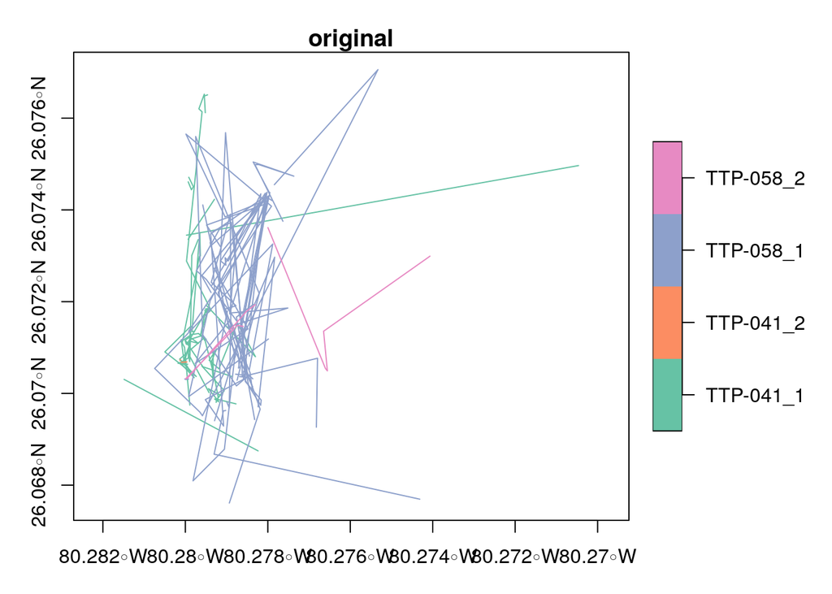

```r
plot(my_sftraj, main ='original', axes = T)
```

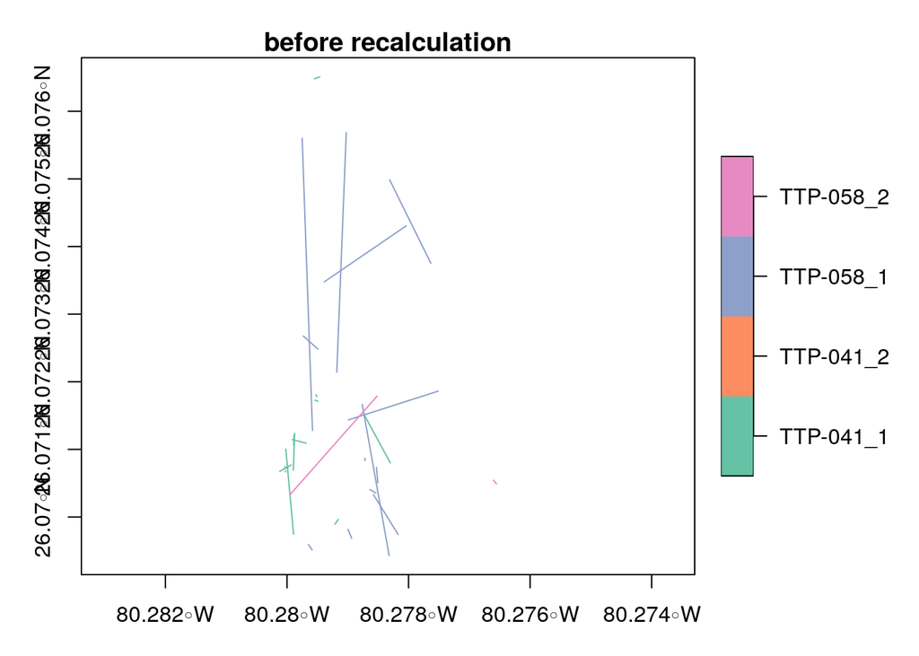

```r
new_traj <- my_sftraj[seq(10,nrow(my_sftraj),10),]

plot(new_traj, main ='before recalculation', axes = T)
```

```r
#plot(step_recalc(new_traj),  main ='after recalculation', axes = T)
```

### Some basic functionality of sf_track and sf_traj objects

##### print

```r
print(my_sftrack,5,10)
```

```
## Sftrack with 445 features and 12 fields (168 empty geometries)
## Geometry : "geometry" (XY, crs: WGS 84)
## Timestamp : "time" (POSIXct in UTC)
## Burst : "burst" (*id*, *month*)
## -------------------------------
##   animal_id latitude longitude           timestamp height hdop vdop fix month
## 1   TTP-058       NA        NA 2019-01-19 00:02:30     NA  0.0  0.0  NO     1
## 2   TTP-058 26.06945 -80.27906 2019-01-19 01:02:30      7  6.2  3.2  2D     1
## 3   TTP-058       NA        NA 2019-01-19 02:02:30     NA  0.0  0.0  NO     1
## 4   TTP-058       NA        NA 2019-01-19 03:02:30     NA  0.0  0.0  NO     1
## 5   TTP-058 26.06769 -80.27431 2019-01-19 04:02:30    858  5.1  3.2  2D     1
##                  time                   burst                   geometry
## 1 2019-01-19 00:02:30 (id: TTP-058, month: 1)                POINT EMPTY
## 2 2019-01-19 01:02:30 (id: TTP-058, month: 1) POINT (-80.27906 26.06945)
## 3 2019-01-19 02:02:30 (id: TTP-058, month: 1)                POINT EMPTY
## 4 2019-01-19 03:02:30 (id: TTP-058, month: 1)                POINT EMPTY
## 5 2019-01-19 04:02:30 (id: TTP-058, month: 1) POINT (-80.27431 26.06769)
```

##### summary

`summary()` works as youd expect for a data.frame, except it displays the burst column as a count of each active_burst combination and the `active_burst`for that column.

```r
summary(my_sftrack)
```

```
##   animal_id            latitude       longitude
##  Length:445         Min.   :26.07   Min.   :-80.28
##  Class :character   1st Qu.:26.07   1st Qu.:-80.28
##  Mode  :character   Median :26.07   Median :-80.28
##                     Mean   :26.07   Mean   :-80.28
##                     3rd Qu.:26.07   3rd Qu.:-80.28
##                     Max.   :26.08   Max.   :-80.27
##                     NA's   :168     NA's   :168
##    timestamp                       height             hdop
##  Min.   :2019-01-19 00:02:30   Min.   : -30.00   Min.   :0.000
##  1st Qu.:2019-01-22 07:02:30   1st Qu.:   1.00   1st Qu.:0.000
##  Median :2019-01-25 23:02:30   Median :   7.00   Median :1.300
##  Mean   :2019-01-25 22:22:18   Mean   :  36.65   Mean   :1.691
##  3rd Qu.:2019-01-29 07:02:09   3rd Qu.:  15.50   3rd Qu.:2.500
##  Max.   :2019-02-01 23:02:30   Max.   :1107.00   Max.   :9.900
##                                NA's   :198
##       vdop       fix          month            time
##  Min.   :0.000   2D: 37   Min.   :1.000   Min.   :2019-01-19 00:02:30
##  1st Qu.:0.000   3D:240   1st Qu.:1.000   1st Qu.:2019-01-22 07:02:30
##  Median :1.900   NO:168   Median :1.000   Median :2019-01-25 23:02:30
##  Mean   :1.938            Mean   :1.067   Mean   :2019-01-25 22:22:18
##  3rd Qu.:3.200            3rd Qu.:1.000   3rd Qu.:2019-01-29 07:02:09
##  Max.   :8.400            Max.   :2.000   Max.   :2019-02-01 23:02:30
##
##                      burst              geometry
##  TTP-041_1              :208   POINT        :445
##  TTP-041_2              : 15   epsg:NA      :  0
##  TTP-058_1              :207   +proj=long...:  0
##  TTP-058_2              : 15
##  active_burst: id, month:  0
##
##
```

##### summary_sftrack

`summary_sftrack()` is a special summary function specific for sftrack objects. It summarizes the data based on the beginning and end of each burst as well as the total distance of the burst. This function uses `st_distance` from the `sf` package and therefore outputs in units of the crs. In this example the distance is in meters.

```r
summary_sftrack(my_sftrack)
```

```
##       burst points NAs          begin_time            end_time    length_m
## 1 TTP-041_1    208   0 2019-01-19 00:02:30 2019-01-31 23:02:30 10108.95506
## 2 TTP-041_2     15   0 2019-02-01 00:02:30 2019-02-01 23:02:07    32.31794
## 3 TTP-058_1    207   0 2019-01-19 00:02:30 2019-01-31 23:02:30 24666.45395
## 4 TTP-058_2     15   0 2019-02-01 00:02:30 2019-02-01 23:02:30  1924.48555
```

You can also trigger this function by using `summary(data, stats = TRUE)`

```r
summary(my_sftrack, stats = TRUE)
```

```
##       burst points NAs          begin_time            end_time    length_m
## 1 TTP-041_1    208   0 2019-01-19 00:02:30 2019-01-31 23:02:30 10108.95506
## 2 TTP-041_2     15   0 2019-02-01 00:02:30 2019-02-01 23:02:07    32.31794
## 3 TTP-058_1    207   0 2019-01-19 00:02:30 2019-01-31 23:02:30 24666.45395
## 4 TTP-058_2     15   0 2019-02-01 00:02:30 2019-02-01 23:02:30  1924.48555
```